# Using dabestr

How to create estimation plots

Joses Ho

2020-07-13

# Create Data

For this vignette, we will create and use a synthetic dataset.

```r
library(dplyr)

set.seed(54321)

N = 40
c1 <- rnorm(N, mean = 100, sd = 25)
c2 <- rnorm(N, mean = 100, sd = 50)
g1 <- rnorm(N, mean = 120, sd = 25)
g2 <- rnorm(N, mean = 80, sd = 50)
g3 <- rnorm(N, mean = 100, sd = 12)
g4 <- rnorm(N, mean = 100, sd = 50)
gender <- c(rep('Male', N/2), rep('Female', N/2))
dummy <- rep("Dummy", N)
id <- 1: N


wide.data <-
  tibble::tibble(
    Control1 = c1, Control2 = c2,
    Group1 = g1, Group2 = g2, Group3 = g3, Group4 = g4,
    Dummy = dummy,
    Gender = gender, ID = id)


my.data   <-
  wide.data %>%
  tidyr::gather(key = Group, value = Measurement, -ID, -Gender, -Dummy)

head(my.data)
```

```
## # A tibble: 6 x 5
##   Dummy Gender    ID Group    Measurement
##   <chr> <chr>  <int> <chr>          <dbl>
## 1 Dummy Male       1 Control1        95.5
## 2 Dummy Male       2 Control1        76.8
## 3 Dummy Male       3 Control1        80.4
## 4 Dummy Male       4 Control1        58.7
## 5 Dummy Male       5 Control1        89.8
## 6 Dummy Male       6 Control1        72.6
```

This dataset is a [tidy dataset](https://vita.had.co.nz/papers/tidy-data.html), where each observation (datapoint) is a row, and each variable (or associated metadata) is a column. `dabestr` requires that data be in this form, as do [other popular R packages](https://www.tidyverse.org) for data visualization and analysis.

# The Gardner-Altman Two Group Estimation Plot

## Unpaired

The `dabest` function is the main workhorse of the `dabestr` package. To create a two-group estimation plot (*aka* a [Gardner-Altman plot](https://en.wikipedia.org/wiki/Estimation_statistics#Gardner-Altman_plot)), we must first specify the following:

- the `x` and `y` columns,
- whether the comparison is `paired = TRUE` or `paired = FALSE`,
- and the groups to be compared via `idx`.

```r
library(dabestr)
two.group.unpaired <-
  my.data %>%
  dabest(Group, Measurement,
         # The idx below passes "Control" as the control group,
         # and "Group1" as the test group. The mean difference
         # will be computed as mean(Group1) - mean(Control1).
         idx = c("Control1", "Group1"),
         paired = FALSE)

# Calling the object automatically prints out a summary.
two.group.unpaired
```

```
## dabestr (Data Analysis with Bootstrap Estimation in R) v0.3.0
## =============================================================
##
## Good morning!
## The current time is 11:27 AM on Monday July 13, 2020.
##
## Dataset    :  .
## The first five rows are:
## # A tibble: 5 x 5
##   Dummy Gender    ID Group    Measurement
##   <chr> <chr>  <int> <fct>          <dbl>
## 1 Dummy Male       1 Control1        95.5
## 2 Dummy Male       2 Control1        76.8
## 3 Dummy Male       3 Control1        80.4
## 4 Dummy Male       4 Control1        58.7
## 5 Dummy Male       5 Control1        89.8
##
## X Variable :  Group
## Y Variable :  Measurement
##
## Effect sizes(s) will be computed for:
##   1. Group1 minus Control1
```

To compute the mean difference between `Group1` and `Control1`, we apply the `mean_diff()` function to the `dabest` object created above.

```r
two.group.unpaired.meandiff <- mean_diff(two.group.unpaired)

# Calling the above object produces a textual summary of the computed effect size.
two.group.unpaired.meandiff
```

```
## dabestr (Data Analysis with Bootstrap Estimation in R) v0.3.0
## =============================================================
##
## Good morning!
## The current time is 11:27 AM on Monday July 13, 2020.
##
## Dataset    :  .
## X Variable :  Group
## Y Variable :  Measurement
##
## Unpaired mean difference of Group1 (n = 40) minus Control1 (n = 40)
##  19.2 [95CI  7.62; 30.6]
##
##
## 5000 bootstrap resamples.
## All confidence intervals are bias-corrected and accelerated.
```

As of `dabest` v0.3.0, there are five effect sizes available:

- The mean difference, given by `mean_diff()`.
- The median difference, given by `median_diff()`.
- Cohen’s d, given by `cohens_d()`.
- Hedges’ g, given by `hedges_g()`.
- Cliff’s delta, given by `cliffs_delta()`.

To create a two-group estimation plot (*aka* a [Gardner-Altman plot](https://en.wikipedia.org/wiki/Estimation_statistics#Gardner-Altman_plot)) from this data, simply use `plot(dabest_effsize.object)`.

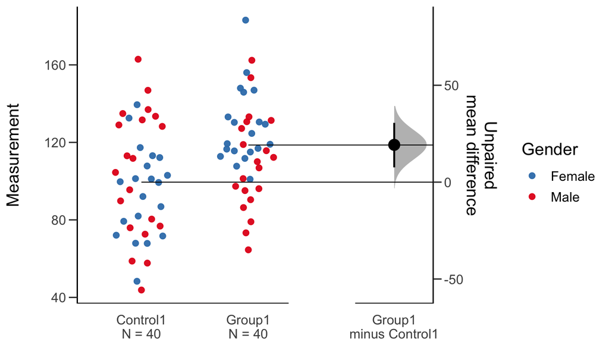

```r
plot(two.group.unpaired.meandiff, color.column = Gender)
```

This is known as a Gardner-Altman estimation plot, after [Martin J. Gardner](https://www.independent.co.uk/news/people/obituary-professor-martin-gardner-1470261.html) and [Douglas Altman](https://www.bmj.com/content/361/bmj.k2588) who were the first to [publish it](https://www.bmj.com/content/bmj/292/6522/746.full.pdf) in 1986.

The key features of the Gardner-Altman estimation plot are:

1. All data points are plotted.
2. The mean difference (the effect size) and its 95% confidence interval (95% CI) is displayed as a point estimate and vertical bar respectively, on a separate but aligned axes.

The estimation plot produced by `dabest` differs from the one first introduced by Gardner and Altman in one important aspect. `dabest` derives the 95% CI through nonparametric bootstrap resampling. This enables visualization of the confidence interval as a graded sampling distribution.

The 95% CI presented is bias-corrected and accelerated (ie. a BCa bootstrap). You can read more about bootstrap resampling and BCa correction [here](https://acclab.github.io/bootstrap-confidence-intervals.html).

You can also obtain Gardner-Altman plots for the median difference, Cohen’s *d*, and Hedges’ *g* effect sizes. Below we demonstrate how to obtain one for the Hedges’ *g* of the loaded `two.group.unpaired` dataset.

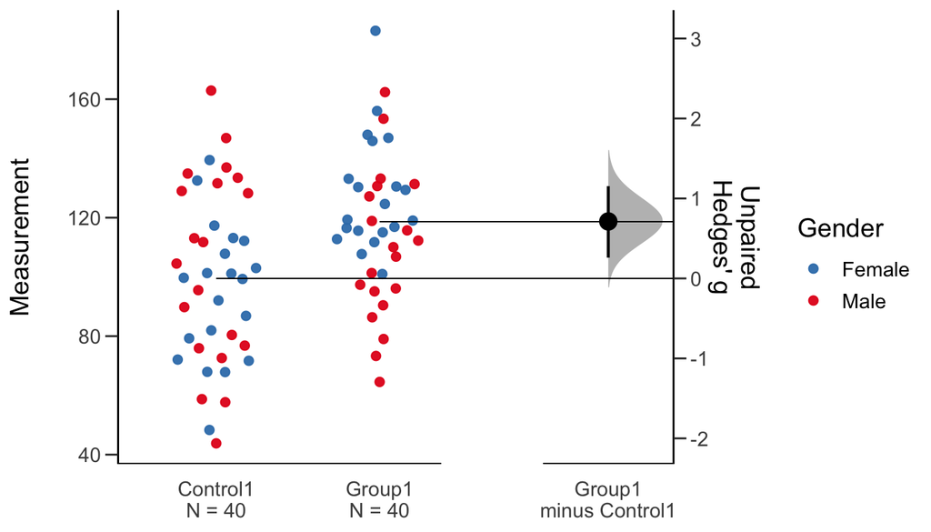

```r
two.group.unpaired %>% hedges_g() %>% plot(color.column = Gender)
```

## Paired

If you have paired or repeated observations, you must specify the `id.col`, a column in the data that indicates the identity of each paired observation. This will produce a [Tufte slopegraph](http://charliepark.org/slopegraphs/) instead of a swarmplot.

```r
two.group.paired <-
  my.data %>%
  dabest(Group, Measurement,
         idx = c("Control1", "Group1"),
         paired = TRUE, id.col = ID)


# The summary indicates this is a paired comparison.
two.group.paired
```

```
## dabestr (Data Analysis with Bootstrap Estimation in R) v0.3.0
## =============================================================
##
## Good morning!
## The current time is 11:27 AM on Monday July 13, 2020.
##
## Dataset    :  .
## The first five rows are:
## # A tibble: 5 x 5
##   Dummy Gender    ID Group    Measurement
##   <chr> <chr>  <int> <fct>          <dbl>
## 1 Dummy Male       1 Control1        95.5
## 2 Dummy Male       2 Control1        76.8
## 3 Dummy Male       3 Control1        80.4
## 4 Dummy Male       4 Control1        58.7
## 5 Dummy Male       5 Control1        89.8
##
## X Variable :  Group
## Y Variable :  Measurement
##
## Paired effect size(s) will be computed for:
##   1. Group1 minus Control1
```

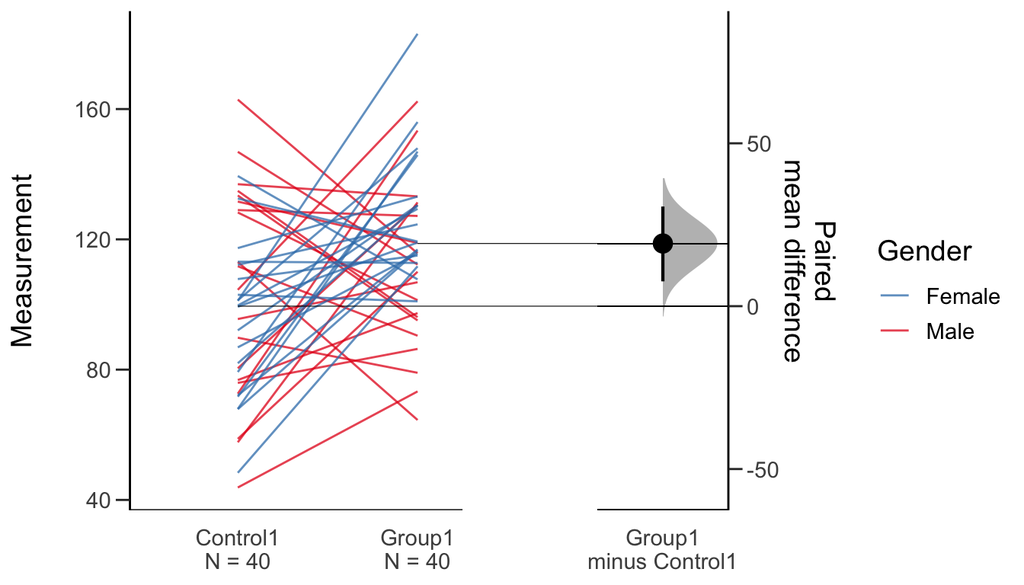

```r
# Create a paired plot.
two.group.paired %>%
  mean_diff() %>%
  plot(color.column = Gender)
```

# The Cummings estimation plot

## Multi-two group

To create a multi-two group plot, one will need to specify a list, with each element of the list corresponding to the each two-group comparison.

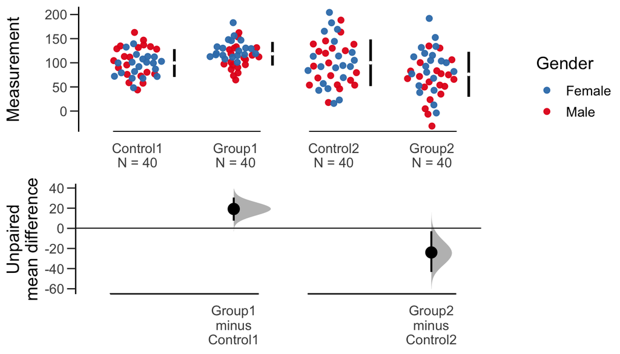

```r
multi.two.group.unpaired <-
  my.data %>%
  dabest(Group, Measurement,
         idx = list(c("Control1", "Group1"),
                    c("Control2", "Group2")),
         paired = FALSE)


# Compute the mean difference.
multi.two.group.unpaired.meandiff <- mean_diff(multi.two.group.unpaired)


# Create a multi-two group plot.
multi.two.group.unpaired.meandiff %>%
  plot(color.column = Gender)
```

This is a Cumming estimation plot. It is heavily influenced by the plot designs of [Geoff Cumming](https://www.youtube.com/watch?v=nDN-hcKR7j8) in his 2012 text [Understanding the New Statistics](https://www.routledge.com/Understanding-The-New-Statistics-Effect-Sizes-Confidence-Intervals-and/Cumming/p/book/9780415879682). The effect size and 95% CIs are plotted a separate axes that is now positioned below the raw data. In addition, summary measurements are displayed as gapped lines to the right of each group. These vertical lines are identical to conventional mean ± standard deviation error bars. Here, the mean of each group is indicated as a gap in the line, drawing inspiration from Edward Tufte’s low data-ink ratio dictum.

By default, `dabestr` plots the mean ± standard deviation of each group as a gapped line beside each group. The `group.summaries = 'median_quartiles'` parameter will plot the median and 25th & 75th percentiles of each group is plotted instead. If `group.summaries = NULL`, the summaries are not shown.

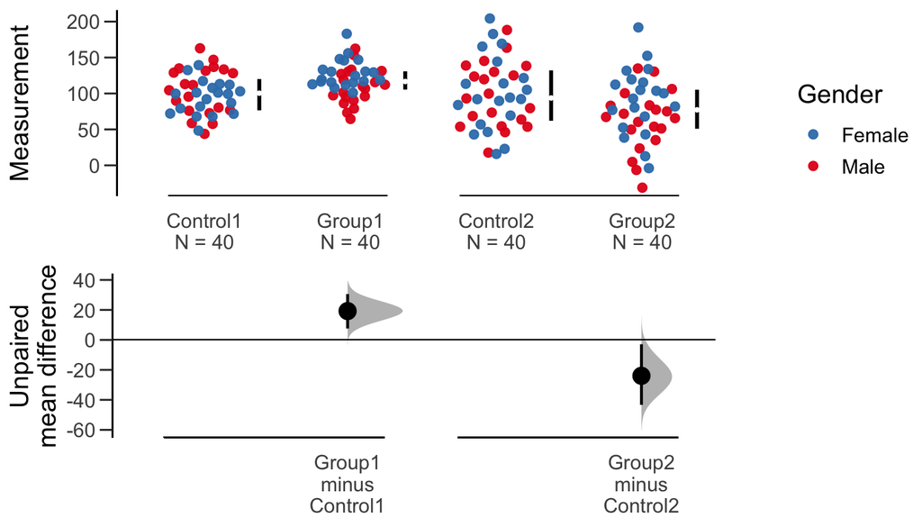

```r
plot(multi.two.group.unpaired.meandiff,
     color.column = Gender,
     group.summaries = "median_quartiles")
```

## Multi-paired

One can also produce a multi-paired plot.

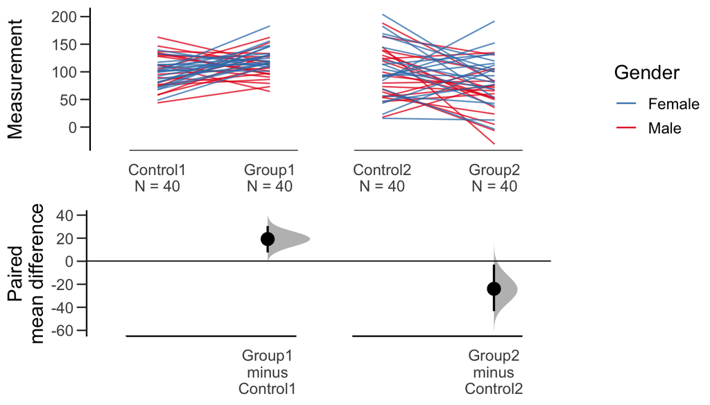

```r
multi.two.group.paired <-
  my.data %>%
  dabest(Group, Measurement,
         idx = list(c("Control1", "Group1"),
                    c("Control2", "Group2")),
         paired = TRUE, id.col = ID
         )


multi.two.group.paired.mean_diff <- mean_diff(multi.two.group.paired)


plot(multi.two.group.paired.mean_diff,
     color.column = Gender,
     slopegraph = TRUE)
```

## Shared Control

If you supply a character vector to `idx` with more than 2 groups, a *shared control* plot will be produced.

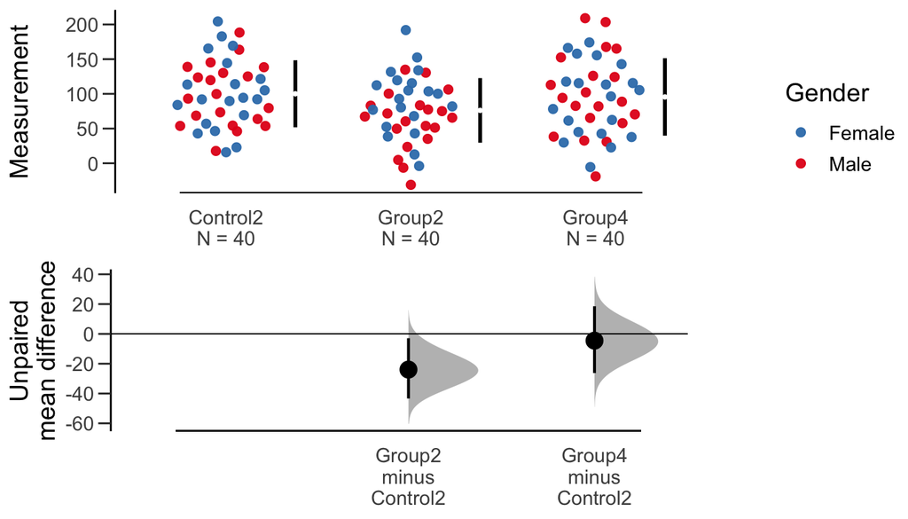

```r
shared.control <-
  my.data %>%
  dabest(Group, Measurement,
         idx = c("Control2", "Group2", "Group4"),
         paired = FALSE
         )

shared.control.mean_diff <- shared.control %>% mean_diff()

plot(shared.control.mean_diff,
     color.column = Gender,
     rawplot.type = "swarmplot")
```

## Multi-group plot

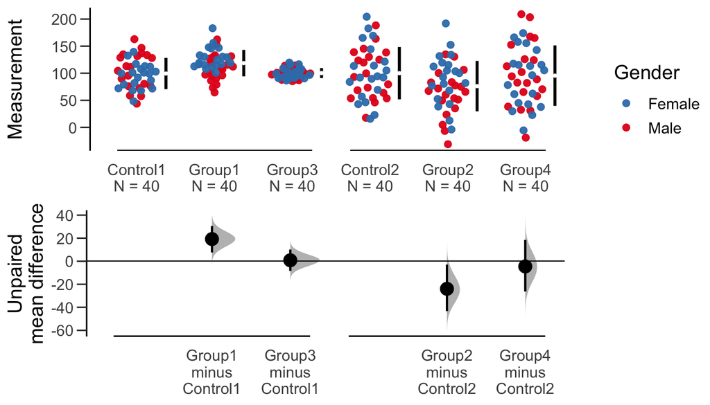

```r
multi.group <-
  my.data %>%
  dabest(Group, Measurement,
         idx = list(c("Control1", "Group1", "Group3"),
                    c("Control2", "Group2", "Group4")),
         paired = FALSE
        )

multi.group.mean_diff <- multi.group %>% mean_diff()

plot(multi.group.mean_diff, color.column = Gender)
```

# Controlling Aesthetics

You can control several graphical aspects of the estimation plot.

Use the `rawplot.ylim` and `effsize.ylim` parameters to supply custom y-limits for the rawplot and the delta plot, respectively.

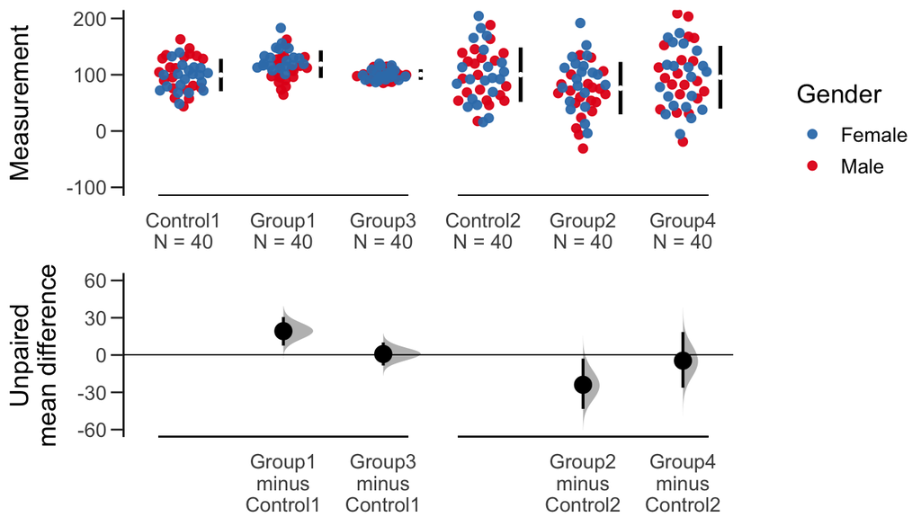

```r
plot(multi.group.mean_diff,
     color.column = Gender,
     rawplot.ylim = c(-100, 200),
     effsize.ylim = c(-60, 60)
    )
```

You can control the size of the dots used to create the rawplot data with `rawplot.markersize`. The default size (in points) is 2.

To obtain an aesthetically-pleasing plot, You should use this option in tandem with the `rawplot.groupwidth` option. This sets the maximum amount that each group of datapoints is allowed to spread in the x-direction. The default is 0.3.

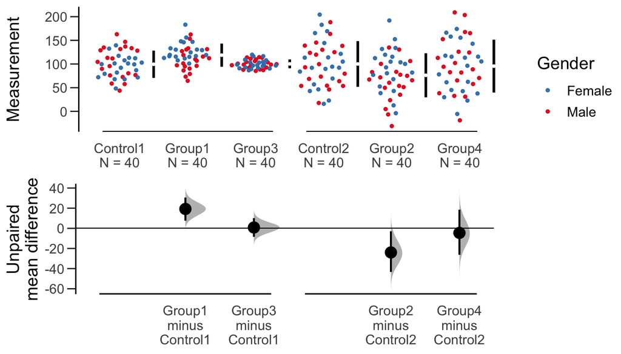

```r
plot(multi.group.mean_diff,
     color.column = Gender,
     rawplot.markersize = 1,
     rawplot.groupwidth = 0.4
    )
```

The `rawplot.ylabel` and `effsize.ylabel` parameters control the y-axis titles for the rawplot and the delta plot, respectively.

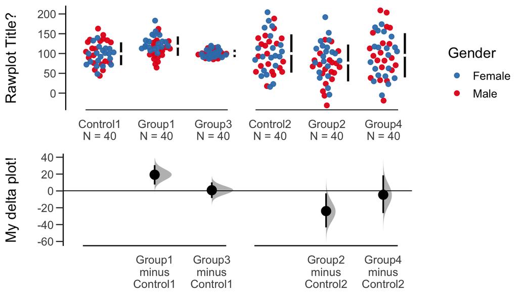

```r
plot(multi.group.mean_diff,
     color.column = Gender,
     rawplot.ylabel = "Rawplot Title?",
     effsize.ylabel = "My delta plot!"
    )
```

The `axes.title.fontsize` parameter determines the fontsize of both the rawplot and deltaplot y-axes titles.

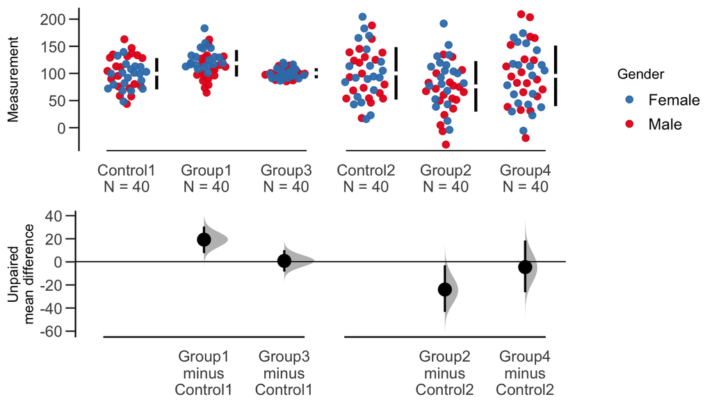

```r
plot(multi.group.mean_diff,
     color.column = Gender,
     axes.title.fontsize = 10 # default is 14.
    )
```

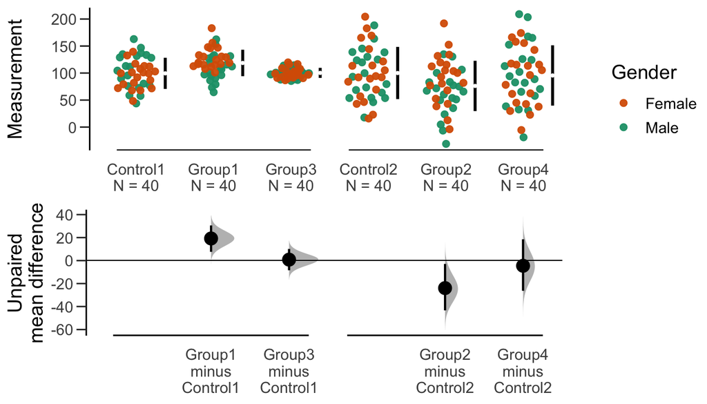

```r
plot(multi.group.mean_diff,
     color.column = Gender,
     palette = "Dark2" # The default is "Set1".
     )
```

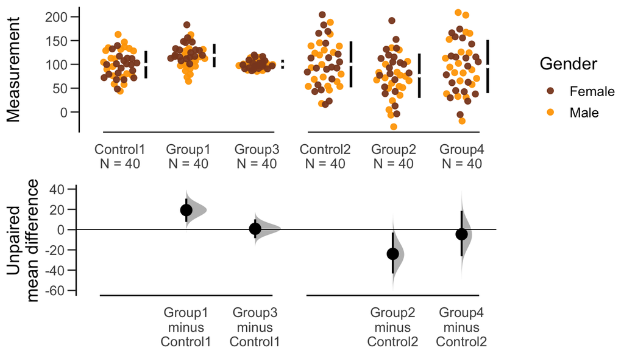

```r
plot(multi.group.mean_diff,
     color.column = Gender,
     # A custom palette consisting of a vector of colors,
     # specified as RGB hexcode, or as a R named color.
     # See all 657 named R colors with `colors()`.
     palette = c("#FFA500", "sienna4")
     )
```

You can use the `theme` parameter to pass along any ggplot2 themes. The default `ggplot2` theme is `theme_classic()`.

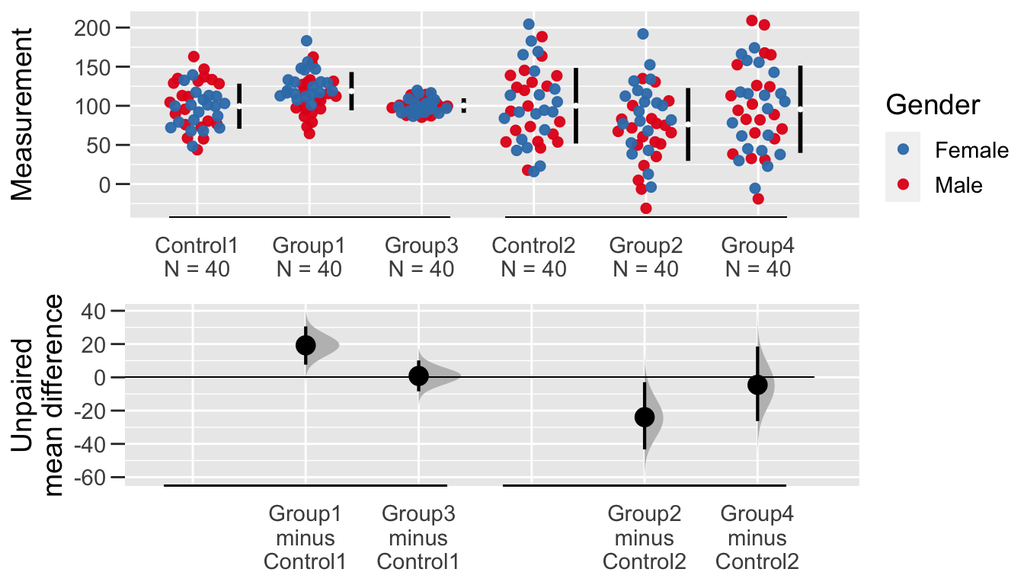

```r
plot(multi.group.mean_diff,
     color.column = Gender,
     theme = ggplot2::theme_gray()
     )
```

# Further Reading

Read more about how the estimation plot combines [statistical rigour and visual design](https://acclab.github.io/robust-statistical-visualization.html). You might also be interested in finding out more about [bootstrap confidence intervals](https://acclab.github.io/bootstrap-confidence-intervals.html).